# Homework 6:五大联赛球员数据分析

20210980108 颜帆

背景介绍：数据集文件soccer.csv为2018-2019赛季的数据欧洲足球五大联赛球员的比赛数据，包括了1563个足球运动员（不包括门将）在该赛季的身价、射门、射正、进球、偷球、关键传球、带球摆脱、助攻、被侵犯、解围、拦截、封堵、头球、铲断的数据。因变量为身价，单位为千万英镑。其余为自变量，均为连续变量，单位均为次。

分析任务：

1. 读入五大联赛数据集soccer.csv；
2. 绘制自变量的相关系数图并解读；
3. 对所有的自变量（除身价外）进行主成分分析，选择主成分个数时使用碎石图的方法，并对结果进行解读；
4. 根据任务2的结果，计算每一位球员的主成分得分，并挑选几位球员进行解读；
5. 使用计算得到的主成分得分，对足球运动员进行K-means聚类，并对结果进行解读。

## 分析任务一

读入五大联赛数据集soccer.csv

系统中没有这个SimHei等中文字体，因为是在实验室的机器上，下载字体没弄出来，在matplotlib中不能体现中文，但图下方的坐标均有解释。

```python
import numpy as np
import pandas as pd
import matplotlib.pyplot as plt
import seaborn as sns
from pandas import Series
from factor_analyzer.factor_analyzer import calculate_bartlett_sphericity
from factor_analyzer import FactorAnalyzer
from sklearn.decomposition import PCA
from sklearn.cluster import KMeans
from mpl_toolkits.mplot3d import Axes3D  # 绘制3D图形
from sklearn import metrics
%matplotlib inline
#plt.rcParams['font.sans-serif'] = ['SimHei']     ##系统里没有这个字体，所以会有一些小bug，在plot中不能体现中文。
plt.rcParams['font.sans-serif'] = ['DejaVu Sans']
plt.rcParams['axes.unicode_minus'] = False
```

```python
#读入数据
x = pd.read_csv('soccer.csv',encoding ='utf-8')
x
```

|  | Unnamed: 0 | 球员 | 身价 | 射门 | 射正 | 进球 | 偷球 | 关键传球 | 带球摆脱 | 助攻 | 被侵犯 | 解围 | 拦截 | 封堵 | 头球 | 铲断 |
| --- | --- | --- | --- | --- | --- | --- | --- | --- | --- | --- | --- | --- | --- | --- | --- | --- |
| 0 | 1 | 托马斯 | 180.0 | 32 | 9 | 5 | 15 | 8 | 5 | 1 | 13 | 11 | 5 | 5 | 47 | 15 |
| 1 | 2 | M.加西亚 | 162.0 | 30 | 7 | 2 | 27 | 12 | 12 | 1 | 53 | 59 | 26 | 7 | 107 | 83 |
| 2 | 3 | 马丁阿古拉甘 | 135.0 | 1 | 0 | 0 | 10 | 8 | 25 | 0 | 28 | 56 | 26 | 11 | 20 | 42 |
| 3 | 4 | 伊利 | 540.0 | 2 | 1 | 0 | 0 | 2 | 0 | 0 | 2 | 25 | 8 | 7 | 24 | 7 |
| 4 | 5 | 迭戈.罗兰 | 315.0 | 10 | 2 | 0 | 15 | 5 | 12 | 0 | 17 | 8 | 4 | 0 | 9 | 13 |
| ... | ... | ... | ... | ... | ... | ... | ... | ... | ... | ... | ... | ... | ... | ... | ... | ... |
| 1558 | 1710 | 罗德里格斯 | 1350.0 | 27 | 6 | 0 | 18 | 21 | 11 | 3 | 19 | 77 | 36 | 5 | 41 | 55 |
| 1559 | 1711 | 孔蒂 | 1350.0 | 0 | 0 | 0 | 0 | 6 | 4 | 2 | 4 | 9 | 15 | 0 | 10 | 9 |
| 1560 | 1712 | 大卫卡拉 | 1170.0 | 10 | 2 | 1 | 18 | 20 | 10 | 1 | 18 | 60 | 31 | 1 | 15 | 81 |
| 1561 | 1713 | 比格利亚 | 1350.0 | 7 | 2 | 1 | 12 | 12 | 3 | 0 | 16 | 23 | 22 | 3 | 10 | 57 |
| 1562 | 1714 | 拉克索尔特 | 1080.0 | 6 | 3 | 0 | 11 | 8 | 6 | 0 | 6 | 9 | 4 | 3 | 6 | 24 |

1563 rows × 16 columns

```python
x.describe()
```

|  | Unnamed: 0 | 身价 | 射门 | 射正 | 进球 | 偷球 | 关键传球 | 带球摆脱 | 助攻 | 被侵犯 | 解围 | 拦截 | 封堵 | 头球 | 铲断 |
| --- | --- | --- | --- | --- | --- | --- | --- | --- | --- | --- | --- | --- | --- | --- | --- |
| count | 1563.000000 | 1563.000000 | 1563.000000 | 1563.000000 | 1563.000000 | 1563.000000 | 1563.000000 | 1563.000000 | 1563.000000 | 1563.000000 | 1563.000000 | 1563.000000 | 1563.000000 | 1563.000000 | 1563.000000 |
| mean | 854.679463 | 1221.104671 | 22.939859 | 7.953295 | 2.502239 | 18.010877 | 17.009597 | 14.701216 | 1.705054 | 20.619322 | 34.915547 | 19.321177 | 5.570697 | 30.467690 | 29.769674 |
| std | 494.845649 | 1760.249746 | 24.649896 | 10.285228 | 3.941209 | 18.443894 | 17.512916 | 17.006805 | 2.218394 | 17.826423 | 41.540647 | 17.048676 | 7.190607 | 31.294613 | 23.111336 |
| min | 1.000000 | 0.000000 | 0.000000 | 0.000000 | 0.000000 | 0.000000 | 0.000000 | 0.000000 | 0.000000 | 0.000000 | 0.000000 | 0.000000 | 0.000000 | 0.000000 | 0.000000 |
| 25% | 427.500000 | 225.000000 | 6.000000 | 1.000000 | 0.000000 | 4.000000 | 4.000000 | 3.000000 | 0.000000 | 7.000000 | 6.000000 | 5.000000 | 1.000000 | 8.000000 | 12.000000 |
| 50% | 851.000000 | 630.000000 | 15.000000 | 4.000000 | 1.000000 | 12.000000 | 11.000000 | 9.000000 | 1.000000 | 16.000000 | 19.000000 | 15.000000 | 3.000000 | 21.000000 | 25.000000 |
| 75% | 1283.500000 | 1350.000000 | 31.000000 | 10.000000 | 3.000000 | 27.000000 | 25.000000 | 20.000000 | 2.000000 | 29.000000 | 47.000000 | 29.000000 | 8.000000 | 43.000000 | 43.000000 |
| max | 1714.000000 | 18000.000000 | 175.000000 | 87.000000 | 36.000000 | 136.000000 | 111.000000 | 147.000000 | 14.000000 | 111.000000 | 241.000000 | 86.000000 | 55.000000 | 234.000000 | 143.000000 |

如上表，数据一共有1563行，代表1563个球员一个赛季的数据；一共统计了十五个变量，包括球员姓名，因变量球员身价和十三个自变量。

## 分析任务二

绘制自变量的相关系数图并解读

```python
X = x.iloc[:,3:]   ## 自变量X
cor = X.corr()
```

[output not shown]

[output cut: 49 more lines]

[output not shown]

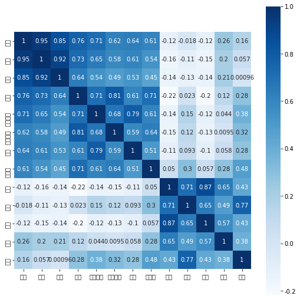

```python
## 自变量的相关系数图
plt.subplots(figsize=(9, 9))
sns.heatmap(cor, annot=True, vmax=1, square=True, cmap="Blues")
plt.show()
```

相关系数图如上，横纵坐标均为自变量的名字。颜色越深代表数值越大，相关性越高。 很明显的可以看出，前八个自变量之间两两的相关系数较高，后五个自变量的相关系数较高，从数据的实际意义上来看，前八个变量包括关键传球，带球摆脱，助攻等，可以理解为一个球员的进攻能力，特别是颜色更深的前三个变量，分别为射门、射正和进球，很明显，这三个变量肯定很相关，实际中，射门次数越多，射正球门的次数也就会越多，若没被守门员守出来，进球数就越多，因此三个变量的相关系数都特别大，表现出强烈的正相关关系。后五个变量为解围、拦截、封堵、头球、铲断，实际中这些动作次数一般都由防守球员如后场球员等来做的，可以理解为球员的防守能力，由于足球场上的角色不同，球员数据的重点偏向也不同，相关系数图很好的展现了这些数据的相关性。

## 分析任务三

对所有的自变量（除身价外）进行主成分分析，选择主成分个数时使用碎石图的方法，并对结果进行解读；

```python
#自变量X的标准化
X_scaled = X.apply(lambda x:(x-x.mean())/x.std())
```

```python
#充分性检测
print('巴特利球形度检验')
from factor_analyzer.factor_analyzer import calculate_bartlett_sphericity
chi_square_value,p_value=calculate_bartlett_sphericity(X_scaled)
print('卡方值：',chi_square_value,'P值', p_value)

#相关性检验kmo要大于0.6
from factor_analyzer.factor_analyzer import calculate_kmo
kmo_all,kmo_model=calculate_kmo(X_scaled)
print('KMO检验：',kmo_model)
```

```
巴特利球形度检验
卡方值： 21588.085312207822 P值 0.0
KMO检验： 0.8450295779388507
```

巴特利球形度检验的P值小于0.05，于是我们认为原自变量中存在相关性，适合做主成分分析。同时，KMO值意味着变量间的相关性，值大于0.8表示该数据适合做主成分分析。

```python
from factor_analyzer import FactorAnalyzer
#查看相关矩阵特征值
fa = FactorAnalyzer(13, rotation='varimax',method='principal',impute='mean')
fa.fit(X_scaled)
ev, v = fa.get_eigenvalues()
print('相关矩阵特征向量：',v)
```

```
相关矩阵特征向量： [5.82362257 3.48751325 1.28057881 0.60849553 0.4195536  0.35071117
 0.29351303 0.19069828 0.17732669 0.13190322 0.10830436 0.09824521
 0.0295343 ]
```

```
findfont: Font family ['Arial Unicode MS'] not found. Falling back to DejaVu Sans.
findfont: Font family ['Arial Unicode MS'] not found. Falling back to DejaVu Sans.
findfont: Font family ['Arial Unicode MS'] not found. Falling back to DejaVu Sans.
```

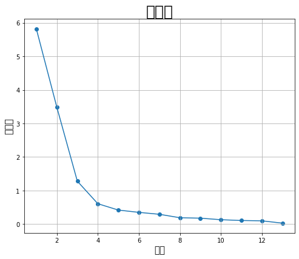

```python
#Create scree plot using matplotlib
plt.figure(figsize=(8, 6.5))
plt.scatter(range(1,X.shape[1]+1),ev)
plt.plot(range(1,X.shape[1]+1),ev)
plt.title('碎石图',fontdict={'weight':'normal','size': 25})
plt.xlabel('因子',fontdict={'weight':'normal','size': 15})
plt.ylabel('特征值',fontdict={'weight':'normal','size': 15})
plt.grid()
plt.show()
```

碎石图如上：横坐标为主成分个数，纵坐标为特征值大小。 主成分个数的选取方式中，常用的一个方式是使用崖底碎石图。根据每个主成分对应的特征值绘制电线图，即当主成分数目从N增加到N+1时，如果特征值出现剧烈的下降，即第N+1个点为拐点，表示相比较于前N个主成分所提取的变量信息，第N+1个主成分只包含了非常少量的变量信息，因此只提取前N个主成分较为合适。由上图的碎石图可以看出，拐点出现在第四个点，因此应该选择三个主成分。

## 分析任务四

根据任务3的结果，计算每一位球员的主成分得分，并挑选几位球员进行解读；

```python
# 进行PCA数据降维
pca = PCA(n_components=3)  # 把维度降至3维
# 进行PCA降维
X_pca = pca.fit_transform(X_scaled)
# 生成降维后的dataframe
X_pca_frame = pd.DataFrame(X_pca, columns=['pca_1', 'pca_2', 'pca_3'])
X_pca_frame.head()
```

|  | pca_1 | pca_2 | pca_3 |
| --- | --- | --- | --- |
| 0 | -0.340186 | -0.869938 | 1.331205 |
| 1 | 1.073838 | 2.575167 | -0.035432 |
| 2 | -1.078620 | 1.098288 | -0.909018 |
| 3 | -2.502700 | -0.691793 | 0.544362 |
| 4 | -1.432614 | -1.506330 | -0.307563 |

```python
X.head()
```

|  | 射门 | 射正 | 进球 | 偷球 | 关键传球 | 带球摆脱 | 助攻 | 被侵犯 | 解围 | 拦截 | 封堵 | 头球 | 铲断 |
| --- | --- | --- | --- | --- | --- | --- | --- | --- | --- | --- | --- | --- | --- |
| 0 | 32 | 9 | 5 | 15 | 8 | 5 | 1 | 13 | 11 | 5 | 5 | 47 | 15 |
| 1 | 30 | 7 | 2 | 27 | 12 | 12 | 1 | 53 | 59 | 26 | 7 | 107 | 83 |
| 2 | 1 | 0 | 0 | 10 | 8 | 25 | 0 | 28 | 56 | 26 | 11 | 20 | 42 |
| 3 | 2 | 1 | 0 | 0 | 2 | 0 | 0 | 2 | 25 | 8 | 7 | 24 | 7 |
| 4 | 10 | 2 | 0 | 15 | 5 | 12 | 0 | 17 | 8 | 4 | 0 | 9 | 13 |

## 分析任务五

使用计算得到的主成分得分，对足球运动员进行K-means聚类，并对结果进行解读。

```python
# KMeans算法实例化，将其设置为K=3（随机选取K=3)
est = KMeans(n_clusters=3)

# 作用到降维后的数据上
est.fit(X_pca)
```

```
KMeans(algorithm='auto', copy_x=True, init='k-means++', max_iter=300,
    n_clusters=3, n_init=10, n_jobs=1, precompute_distances='auto',
    random_state=None, tol=0.0001, verbose=0)
```

```python
# 取出聚类后的标签
kmeans_clustering_labels = pd.DataFrame(est.labels_, columns=['cluster'])

# 生成有聚类后的dataframe
X_pca_frame = pd.concat([X_pca_frame, kmeans_clustering_labels], axis=1)

X_pca_frame.head()
```

|  | pca_1 | pca_2 | pca_3 | cluster |
| --- | --- | --- | --- | --- |
| 0 | -0.340186 | -0.869938 | 1.331205 | 1 |
| 1 | 1.073838 | 2.575167 | -0.035432 | 0 |
| 2 | -1.078620 | 1.098288 | -0.909018 | 0 |
| 3 | -2.502700 | -0.691793 | 0.544362 | 1 |
| 4 | -1.432614 | -1.506330 | -0.307563 | 1 |

```
calinski_harabaz_score with k=2 is 920.764448170312
calinski_harabaz_score with k=3 is 1198.9640170270254
calinski_harabaz_score with k=4 is 1086.824247845333
calinski_harabaz_score with k=5 is 1047.5851387662844
calinski_harabaz_score with k=6 is 993.7454292195202
calinski_harabaz_score with k=7 is 967.1397555434276
calinski_harabaz_score with k=8 is 965.6734306206375
calinski_harabaz_score with k=9 is 930.8854578389821
calinski_harabaz_score with k=10 is 912.8464009274128
calinski_harabaz_score with k=11 is 900.6829123416627
calinski_harabaz_score with k=12 is 877.0941799267275
calinski_harabaz_score with k=13 is 876.38637571524
```

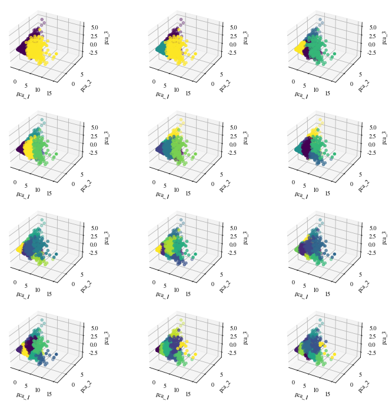

```python
# 对不同的k值进行计算，筛选出最优的K值
from mpl_toolkits.mplot3d import Axes3D  # 绘制3D图形
from sklearn import metrics

# KMeans算法实例化，将其设置为K=range(2, 14)  聚类K值的选取
d = {}
fig_reduced_data = plt.figure(figsize=(12, 12))
for k in range(2, 14):
    est = KMeans(n_clusters=k, random_state=111)
    # 作用到降维后的数据上
    y_pred = est.fit_predict(X_pca)
    # 评估不同k值聚类算法效果
    calinski_harabaz_score = metrics.calinski_harabaz_score(X_pca_frame, y_pred)  # X_pca_frame：表示要聚类的样本数据，一般形如（samples，features）的格式。y_pred：即聚类之后得到的label标签，形如（samples，）的格式
    d.update({k: calinski_harabaz_score})
    print('calinski_harabaz_score with k={0} is {1}'.format(k, calinski_harabaz_score))  # CH score的数值越大越好
    # 生成三维图形，每个样本点的坐标分别是三个主成分的值
    ax = plt.subplot(4, 3, k - 1, projection='3d') #将figure设置的画布大小分成几个部分，表示4(row)x3(colu),即将画布分成4x3，四行三列的12块区域，k-1表示选择图形输出的区域在第k-1块，图形输出区域参数必须在“行x列”范围
    ax.scatter(X_pca_frame.pca_1, X_pca_frame.pca_2, X_pca_frame.pca_3, c=y_pred)  # pca_1、pca_2、pca_3为输入数据，c表示颜色序列
    ax.set_xlabel('pca_1')
    ax.set_ylabel('pca_2')
    ax.set_zlabel('pca_3')
```

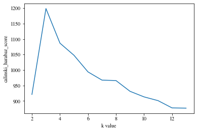

```python
# 绘制不同k值对应的score，找到最优的k值
x = []
y = []
for k, score in d.items():
    x.append(k)
    y.append(score)

plt.plot(x, y)
plt.xlabel('k value')
plt.ylabel('calinski_harabaz_score')
```

由于CH分数：Calinski Harabasz Score（一种用于评判聚类效果的标准）越大，标明聚类效果越好，因此我们选择CH分数最高时的聚类的簇数：K=3，表明将降维后的数据集聚类为三类时，聚类效果最好。

```python
X.index = X_pca_frame.index

# 合并原数据和三个主成分的数据
X_full = pd.concat([X, X_pca_frame], axis=1)
X_full.head()
```

|  | 射门 | 射正 | 进球 | 偷球 | 关键传球 | 带球摆脱 | 助攻 | 被侵犯 | 解围 | 拦截 | 封堵 | 头球 | 铲断 | pca_1 | pca_2 | pca_3 | cluster |
| --- | --- | --- | --- | --- | --- | --- | --- | --- | --- | --- | --- | --- | --- | --- | --- | --- | --- |
| 0 | 32 | 9 | 5 | 15 | 8 | 5 | 1 | 13 | 11 | 5 | 5 | 47 | 15 | -0.340186 | -0.869938 | 1.331205 | 1 |
| 1 | 30 | 7 | 2 | 27 | 12 | 12 | 1 | 53 | 59 | 26 | 7 | 107 | 83 | 1.073838 | 2.575167 | -0.035432 | 0 |
| 2 | 1 | 0 | 0 | 10 | 8 | 25 | 0 | 28 | 56 | 26 | 11 | 20 | 42 | -1.078620 | 1.098288 | -0.909018 | 0 |
| 3 | 2 | 1 | 0 | 0 | 2 | 0 | 0 | 2 | 25 | 8 | 7 | 24 | 7 | -2.502700 | -0.691793 | 0.544362 | 1 |
| 4 | 10 | 2 | 0 | 15 | 5 | 12 | 0 | 17 | 8 | 4 | 0 | 9 | 13 | -1.432614 | -1.506330 | -0.307563 | 1 |

```python
# 按每个聚类分组
grouped = X_full.groupby('cluster')

result_data = pd.DataFrame()
# 对分组做循环，分别对每组进行去除异常值处理
for name, group in grouped:
    # 每组去除异常值前的个数
    print('Group:{0}, Samples before:{1}'.format(name, group['pca_1'].count()))
    desp = group[['pca_1', 'pca_2', 'pca_3']].describe() # 返回每组的数量、均值、标准差、最小值、最大值等数据
    for att in ['pca_1', 'pca_2', 'pca_3']:
        # 去异常值：箱形图
        lower25 = desp.loc['25%', att]
        upper75 = desp.loc['75%', att]
        IQR = upper75 - lower25
        min_value = lower25 - 1.5 * IQR
        max_value = upper75 + 1.5 * IQR
        # 使用统计中的1.5*IQR法则，删除每个聚类中的噪音和异常点
        group = group[(group[att] > min_value) & (group[att] < max_value)]
    result_data = pd.concat([result_data, group], axis=0)
    # 每组去除异常值后的个数
    print('Group:{0}, Samples after:{1}'.format(name, group['pca_1'].count()))
print('Remain sample:', result_data['pca_1'].count())
```

```
Group:0, Samples before:446
Group:0, Samples after:437
Group:1, Samples before:790
Group:1, Samples after:739
Group:2, Samples before:327
Group:2, Samples after:317
Remain sample: 1493
```

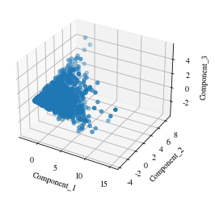

```python
# 原始数据降维后的可视化
from mpl_toolkits.mplot3d import Axes3D

# 生成三维图形，每个样本点的坐标分别是三个主成分的值
fig_reduced_data = plt.figure()
ax_reduced_data = plt.subplot(111, projection='3d')
ax_reduced_data.scatter(X_pca_frame.pca_1.values, X_pca_frame.pca_2.values, X_pca_frame.pca_3.values)
ax_reduced_data.set_xlabel('Component_1')
ax_reduced_data.set_ylabel('Component_2')
ax_reduced_data.set_zlabel('Component_3')
```

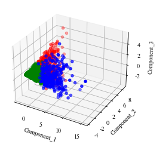

```python
# 设置每个簇对应的颜色
cluster_2_color = {0: 'red', 1: 'green', 2: 'blue', 3: 'yellow', 4: 'cyan', 5: 'black', 6: 'magenta', 7: '#fff0f5',
                   8: '#ffdab9', 9: '#ffa500'}

colors_clustered_data = X_pca_frame.cluster.map(cluster_2_color)  # 簇名和颜色映射
fig_reduced_data = plt.figure()
ax_clustered_data = plt.subplot(111, projection='3d')

# 聚类算法之后的不同簇数据的映射为不同颜色
ax_clustered_data.scatter(X_pca_frame.pca_1.values, X_pca_frame.pca_2.values, X_pca_frame.pca_3.values,
                          c=colors_clustered_data)
ax_clustered_data.set_xlabel('Component_1')
ax_clustered_data.set_ylabel('Component_2')
ax_clustered_data.set_zlabel('Component_3')
```

```python
result_data
```

|  | 射门 | 射正 | 进球 | 偷球 | 关键传球 | 带球摆脱 | 助攻 | 被侵犯 | 解围 | 拦截 | 封堵 | 头球 | 铲断 | pca_1 | pca_2 | pca_3 | cluster |
| --- | --- | --- | --- | --- | --- | --- | --- | --- | --- | --- | --- | --- | --- | --- | --- | --- | --- |
| 1 | 30 | 7 | 2 | 27 | 12 | 12 | 1 | 53 | 59 | 26 | 7 | 107 | 83 | 1.073838 | 2.575167 | -0.035432 | 0 |
| 2 | 1 | 0 | 0 | 10 | 8 | 25 | 0 | 28 | 56 | 26 | 11 | 20 | 42 | -1.078620 | 1.098288 | -0.909018 | 0 |
| 6 | 23 | 8 | 0 | 6 | 26 | 5 | 0 | 61 | 110 | 58 | 12 | 54 | 73 | 0.338970 | 3.758681 | -0.828306 | 0 |
| 7 | 13 | 3 | 2 | 15 | 10 | 15 | 2 | 37 | 132 | 50 | 12 | 49 | 56 | -0.078699 | 3.252042 | -0.354917 | 0 |
| 11 | 17 | 4 | 1 | 4 | 7 | 0 | 2 | 14 | 218 | 52 | 19 | 78 | 48 | -1.157708 | 4.872678 | 1.273916 | 0 |
| ... | ... | ... | ... | ... | ... | ... | ... | ... | ... | ... | ... | ... | ... | ... | ... | ... | ... |
| 1542 | 91 | 41 | 11 | 44 | 78 | 35 | 9 | 32 | 6 | 9 | 1 | 26 | 14 | 6.265503 | -1.896864 | 0.928808 | 2 |
| 1544 | 52 | 16 | 7 | 40 | 44 | 41 | 2 | 31 | 52 | 26 | 10 | 38 | 42 | 2.906590 | 0.723863 | 0.044958 | 2 |
| 1546 | 118 | 52 | 22 | 45 | 29 | 15 | 0 | 56 | 33 | 4 | 5 | 70 | 17 | 5.822612 | -1.014996 | 4.913702 | 2 |
| 1551 | 102 | 26 | 3 | 35 | 84 | 31 | 6 | 38 | 11 | 27 | 5 | 24 | 52 | 5.018838 | -0.098151 | -0.897393 | 2 |
| 1552 | 95 | 40 | 7 | 61 | 98 | 65 | 10 | 80 | 1 | 16 | 1 | 5 | 28 | 8.345958 | -1.436181 | -1.482183 | 2 |

1493 rows × 17 columns

```python
x = pd.read_csv('soccer.csv',encoding ='utf-8')
Y = x.iloc[:,2] #因变量身价
Y
```

```
0        180.0
1        162.0
2        135.0
3        540.0
4        315.0
         ...
1558    1350.0
1559    1350.0
1560    1170.0
1561    1350.0
1562    1080.0
Name: 身价, Length: 1563, dtype: float64
```

```python
Y0 = result_data[result_data['cluster']==0].index  #437个球员  聚类为0的球员的索引
Y1 = result_data[result_data['cluster']==1].index
Y2 = result_data[result_data['cluster']==2].index
```

```python
## 聚类为0的类别的球员的
y0 = []
for i in Y0:
    y0.append(Y[i])
y0 = Series(y0)
y0.describe()
```

```
count     437.000000
mean     1224.743707
std      1430.628285
min         9.000000
25%       270.000000
50%       720.000000
75%      1440.000000
max      8100.000000
dtype: float64
```

```python
result_data[result_data['cluster']==0].describe()
```

|  | 射门 | 射正 | 进球 | 偷球 | 关键传球 | 带球摆脱 | 助攻 | 被侵犯 | 解围 | 拦截 | 封堵 | 头球 | 铲断 | pca_1 | pca_2 | pca_3 | cluster |
| --- | --- | --- | --- | --- | --- | --- | --- | --- | --- | --- | --- | --- | --- | --- | --- | --- | --- |
| count | 437.000000 | 437.000000 | 437.000000 | 437.000000 | 437.000000 | 437.000000 | 437.000000 | 437.000000 | 437.000000 | 437.000000 | 437.000000 | 437.000000 | 437.000000 | 437.000000 | 437.000000 | 437.000000 | 437.0 |
| mean | 16.933638 | 4.569794 | 1.288330 | 13.519451 | 14.977117 | 12.535469 | 1.389016 | 23.704805 | 81.416476 | 38.913043 | 13.006865 | 53.665904 | 50.851259 | -0.324164 | 2.301070 | -0.112448 | 0.0 |
| std | 10.430314 | 3.466458 | 1.263161 | 10.895362 | 12.891731 | 11.374837 | 1.570855 | 14.614850 | 44.448666 | 13.866061 | 7.778909 | 27.836977 | 21.734708 | 1.212613 | 1.324892 | 1.217894 | 0.0 |
| min | 0.000000 | 0.000000 | 0.000000 | 0.000000 | 0.000000 | 0.000000 | 0.000000 | 1.000000 | 8.000000 | 13.000000 | 0.000000 | 5.000000 | 13.000000 | -2.270622 | 0.170834 | -3.481093 | 0.0 |
| 25% | 9.000000 | 2.000000 | 0.000000 | 5.000000 | 5.000000 | 4.000000 | 0.000000 | 13.000000 | 46.000000 | 29.000000 | 7.000000 | 35.000000 | 34.000000 | -1.356952 | 1.237380 | -0.953511 | 0.0 |
| 50% | 15.000000 | 4.000000 | 1.000000 | 10.000000 | 10.000000 | 9.000000 | 1.000000 | 20.000000 | 72.000000 | 37.000000 | 11.000000 | 49.000000 | 49.000000 | -0.488729 | 2.054798 | -0.101396 | 0.0 |
| 75% | 22.000000 | 7.000000 | 2.000000 | 20.000000 | 22.000000 | 18.000000 | 2.000000 | 32.000000 | 110.000000 | 47.000000 | 17.000000 | 69.000000 | 63.000000 | 0.577484 | 3.079967 | 0.763889 | 0.0 |
| max | 74.000000 | 20.000000 | 6.000000 | 49.000000 | 84.000000 | 61.000000 | 8.000000 | 78.000000 | 218.000000 | 86.000000 | 41.000000 | 194.000000 | 143.000000 | 3.048753 | 6.024094 | 3.217309 | 0.0 |

聚类为0的球员数据中，我们可以看到这类球员的射门次数的中位数在15次，射门次数不多，数据更多的在解围，拦截和封堵，中位数分别为72，37，11，大于整体样本的这三个数据的中位数19，15，3。体现了球员的防守能力很强。同时，计算了这类球员的身价分布，可以看到均值在1224千万左右。

```python
## 聚类为1的类别的球员的
y1 = []
for i in Y1:
    y1.append(Y[i])
y1 = Series(y1)
y1.describe()
```

```
count      739.000000
mean       712.083356
std       1016.865644
min          0.000000
25%        135.000000
50%        360.000000
75%        900.000000
max      13500.000000
dtype: float64
```

```python
result_data[result_data['cluster']==1].describe()
```

|  | 射门 | 射正 | 进球 | 偷球 | 关键传球 | 带球摆脱 | 助攻 | 被侵犯 | 解围 | 拦截 | 封堵 | 头球 | 铲断 | pca_1 | pca_2 | pca_3 | cluster |
| --- | --- | --- | --- | --- | --- | --- | --- | --- | --- | --- | --- | --- | --- | --- | --- | --- | --- |
| count | 739.000000 | 739.000000 | 739.000000 | 739.000000 | 739.000000 | 739.000000 | 739.000000 | 739.000000 | 739.000000 | 739.000000 | 739.000000 | 739.000000 | 739.000000 | 739.000000 | 739.000000 | 739.000000 | 739.0 |
| mean | 9.989175 | 3.146143 | 0.843031 | 9.077131 | 8.121786 | 7.108254 | 0.676590 | 10.194858 | 14.775372 | 9.327470 | 2.280108 | 12.841678 | 15.744249 | -1.474953 | -1.101469 | -0.064967 | 1.0 |
| std | 9.854904 | 3.697618 | 1.319949 | 9.164752 | 8.623331 | 7.859482 | 0.993001 | 9.287047 | 15.937663 | 8.174151 | 2.929852 | 11.895803 | 12.697580 | 1.010237 | 0.799126 | 0.439096 | 0.0 |
| min | 0.000000 | 0.000000 | 0.000000 | 0.000000 | 0.000000 | 0.000000 | 0.000000 | 0.000000 | 0.000000 | 0.000000 | 0.000000 | 0.000000 | 0.000000 | -2.725187 | -2.102311 | -1.166836 | 1.0 |
| 25% | 2.000000 | 0.000000 | 0.000000 | 2.000000 | 2.000000 | 1.000000 | 0.000000 | 3.000000 | 3.000000 | 2.000000 | 0.000000 | 3.000000 | 5.000000 | -2.308698 | -1.794610 | -0.332323 | 1.0 |
| 50% | 7.000000 | 2.000000 | 0.000000 | 6.000000 | 5.000000 | 5.000000 | 0.000000 | 8.000000 | 9.000000 | 7.000000 | 1.000000 | 9.000000 | 13.000000 | -1.737701 | -1.312099 | -0.008241 | 1.0 |
| 75% | 15.000000 | 5.000000 | 1.000000 | 14.000000 | 12.000000 | 11.000000 | 1.000000 | 15.000000 | 22.000000 | 15.000000 | 3.000000 | 20.000000 | 23.000000 | -0.822695 | -0.552176 | 0.180605 | 1.0 |
| max | 46.000000 | 19.000000 | 7.000000 | 54.000000 | 61.000000 | 67.000000 | 6.000000 | 55.000000 | 84.000000 | 35.000000 | 15.000000 | 70.000000 | 64.000000 | 1.187407 | 0.962451 | 1.031027 | 1.0 |

这类球员的中位数与全体样本的中位数相比，各项数据都明显更低，再计算其身价，均值在712千万英镑左右，算是足球球员中比较不显眼的存在，且身价较低也符合现实情况

```python
## 聚类为2的类别的球员的
y2 = []
for i in Y2:
    y2.append(Y[i])
y2 = Series(y2)
y2.describe()
```

```
count      317.000000
mean      2366.804416
std       2637.091480
min         45.000000
25%        630.000000
50%       1350.000000
75%       3150.000000
max      18000.000000
dtype: float64
```

```python
result_data[result_data['cluster']==2].describe()
```

|  | 射门 | 射正 | 进球 | 偷球 | 关键传球 | 带球摆脱 | 助攻 | 被侵犯 | 解围 | 拦截 | 封堵 | 头球 | 铲断 | pca_1 | pca_2 | pca_3 | cluster |
| --- | --- | --- | --- | --- | --- | --- | --- | --- | --- | --- | --- | --- | --- | --- | --- | --- | --- |
| count | 317.000000 | 317.000000 | 317.000000 | 317.000000 | 317.000000 | 317.000000 | 317.000000 | 317.000000 | 317.000000 | 317.000000 | 317.000000 | 317.000000 | 317.000000 | 317.000000 | 317.000000 | 317.000000 | 317.0 |
| mean | 58.583596 | 22.511041 | 7.473186 | 43.220820 | 39.552050 | 34.003155 | 4.419558 | 38.712934 | 16.940063 | 15.823344 | 2.694006 | 35.533123 | 33.205047 | 3.602725 | -0.656780 | 0.179336 | 2.0 |
| std | 25.712692 | 11.528612 | 5.196464 | 18.167866 | 17.972059 | 20.991484 | 2.601849 | 18.447057 | 13.363925 | 11.519124 | 2.555287 | 37.673518 | 18.975140 | 1.847701 | 1.020756 | 1.735558 | 0.0 |
| min | 9.000000 | 5.000000 | 0.000000 | 9.000000 | 10.000000 | 2.000000 | 0.000000 | 3.000000 | 0.000000 | 0.000000 | 0.000000 | 0.000000 | 3.000000 | 1.118935 | -3.273931 | -3.180794 | 2.0 |
| 25% | 39.000000 | 14.000000 | 4.000000 | 29.000000 | 28.000000 | 18.000000 | 3.000000 | 25.000000 | 6.000000 | 7.000000 | 1.000000 | 12.000000 | 18.000000 | 2.102427 | -1.426148 | -1.138559 | 2.0 |
| 50% | 55.000000 | 20.000000 | 6.000000 | 41.000000 | 36.000000 | 32.000000 | 4.000000 | 36.000000 | 14.000000 | 13.000000 | 2.000000 | 22.000000 | 31.000000 | 3.014537 | -0.790993 | -0.079890 | 2.0 |
| 75% | 73.000000 | 29.000000 | 10.000000 | 54.000000 | 48.000000 | 46.000000 | 6.000000 | 50.000000 | 24.000000 | 24.000000 | 4.000000 | 44.000000 | 43.000000 | 4.799470 | -0.002114 | 1.358819 | 2.0 |
| max | 175.000000 | 68.000000 | 33.000000 | 136.000000 | 111.000000 | 147.000000 | 13.000000 | 111.000000 | 72.000000 | 64.000000 | 15.000000 | 202.000000 | 96.000000 | 9.122542 | 2.158770 | 4.913702 | 2.0 |